# BISG Mapping Police Violence

John A. Curiel

2024-02-22

# Mapping Police Violence outline

The goal of this module is to learn how to implement Bayesian Improved Surname Geocoding (BISG) imputation of race, in addition to validation exercises. We shall impute race employing Mapping Police Violence data, which in part records race and location.[^1] With these data, we shall cover the general best practices and learn the general error rate.

## Checking and installing relevant packages

The first step when employing BISG is to install the relevant packages. For BISG, we specifically want the “wru” package (“Who are you?”) by Imai and Khanna (2016) in addition to zipWRUext2 by Clark, Curiel and Steelman (2021) for ease of use. Note, because zipWRUext2 relies in part upon the surname dictionary provided by Imai and Khanna’s version 0.1-12, the “special install” section in the block of code below shall ensure that the appropriate version is installed, thereby preventing issues with imputation later on.

```r
### check for packages
pkg <- c("stringr","stringi","tidyverse","foreign","conflicted","data.table","raster","gtools","rgdal",
         "ggplot2","ggpubr","rstudioapi","rgeos","scales","splitstackshape",
         "tidyr","devtools", "sf", "geojsonio","lme4","arm","MASS","knitr")

for (i in pkg){
  print(i)
  if(require(i, character.only=TRUE)){
    print(paste(i, "is loaded correctly"))
  } else{
    print(paste("trying to install", i))
    install.packages(i)
    if(require(i, character.only=TRUE)){
      print(paste(i, "installed and loaded"))
    } else{
      stop(paste("could not install", i))
    }
  }
}
###special install for wru

check_wru <- system.file("wru")

require(devtools)
if(require("wru", character.only=TRUE) & as.numeric(substr(packageVersion("wru"),1,3)) < 1 ){
  print(paste("WRU", "is loaded correctly"))
} else{
  print(paste("trying to install wru"))
  if(check_wru!=""){
    detach("package:wru", unload=TRUE)
    print("Detached another installed version of wru")
  }
  install_version("wru", version = "0.1-12", repos = "http://cran.us.r-project.org")
  ### note: if asked to update other versions, just press 3 to skip
  if(require(i, character.only=TRUE)){
    print(paste("wru installed and loaded"))
  } else{
    stop(paste("could not install wru"))
  }

}

####pkgs to be used
library(foreign)
library(tidyverse)
library(dplyr)
library(raster) # raster (pixel) object handling
library(rgdal) # shapefile access
library(rgeos) # geometry operations
library(stringi) # text processing
library(stringr) # text processing
library(splitstackshape)
library(data.table)
library(ggplot2)
library(scales)
library(conflicted)
library(geojsonio)
library(sf) # simple features for spatial objects
library(lme4)
library(arm)
library(MASS)
library(knitr)
##install the arealOverlap pkg
#devtools::install_github("https://github.com/jcuriel-unc/arealOverlap2",subdir="arealOverlap")
#library(arealOverlap)
library(wru)
##install the zipWRUext2 pkg
#devtools::install_github("https://github.com/jcuriel-unc/zipWRUext",subdir="zipWRUext2")
library(zipWRUext2)

### fxn from zipWRUext; revises to be more flexible than v1 ###
substrRight <- function(x, n){
  substr(x, nchar(x)-n+1, nchar(x))
}
### revision of herfindahl fxn from zipWRUext
race_herfindahl_scores2 <- function (dataframe1)
{
  if (any(colnames(dataframe1) == "pred_whi") == FALSE) {
    stop("Predicted race variable not present.")
  }
  predNames <- c("pred_whi", "pred_bla", "pred_his",
                 "pred_asi", "pred_oth")
  dataframe1 <- as.data.frame(dataframe1)
  dataframe1$herf_weight <- (dataframe1$pred_whi)^2 + (dataframe1$pred_bla)^2 +
    (dataframe1$pred_his)^2 + (dataframe1$pred_asi)^2 + (dataframe1$pred_oth)^2
  dataframe_sub <- subset(dataframe1, select = c(pred_whi,
                                                 pred_bla, pred_his, pred_asi, pred_oth))
  prob_matrix <- as.matrix(dataframe_sub)
  prob_matrix2 <- apply(prob_matrix, 1, max)
  dataframe1 <- cbind(dataframe1, prob_matrix2)
  colnames(dataframe1)[colnames(dataframe1) == "prob_matrix2"] <- "max_race_prob"
  dataframe1$plural_race[dataframe1$pred_whi == dataframe1$max_race_prob] <- "white"
  dataframe1$plural_race[dataframe1$pred_bla == dataframe1$max_race_prob] <- "black"
  dataframe1$plural_race[dataframe1$pred_his == dataframe1$max_race_prob] <- "hispanic"
  dataframe1$plural_race[dataframe1$pred_asi == dataframe1$max_race_prob] <- "asian"
  dataframe1$plural_race[dataframe1$pred_oth == dataframe1$max_race_prob] <- "other"
  return(dataframe1)
}
```

## Loading in the proper data

The next step is to read in and clean the data. These data were downloaded from the Mapping Police Violence site on October 24, 2022 by Logan Harrah as part of his Senior Capstone Project presented at the Western Political Science Conference on April 7, 2023 titled “I’m Armed, Don’t Shoot!”

```r
### read in the data
police <- read.csv("data/mpv_df.csv")
## change name for weapon field
colnames(police)[colnames(police)=="Alleged.Weapon..Source..WaPo.and.Review.of.Cases.Not.Included.in.WaPo.Database."] <-
  "alleged_weapon"
## change weapon field to lower case
police$alleged_weapon <- str_to_lower(police$alleged_weapon)
```

Next, we proceed to clean the name field, which we will need for the “Surname” portion of BISG. Note, we find that there are 226 names withheld. Further, it appears that the name fields were not properly cleaned. Additionally, the police withheld a number of names. We will need to ensure proper cleaned names for the purpose of the surname aspect of BISG.

```r
knitr::kable(head(police[,1:5], 10))
```

| Victim.s.Full.name | First.name | Middle.name.initial | Last.name | Victim.s.age |
| --- | --- | --- | --- | --- |
| Name withheld by police | NA |  |  | 27 |
| Name withheld by police | NA |  |  | Unknown |
| Name withheld by police | NA |  |  | Unknown |
| Ronald W Flowers II | NA | W | Flowers II | Unknown |
| Name withheld by police | NA |  |  | Unknown |
| Name withheld by police | NA |  |  | 31 |
| Name withheld by police | NA |  |  | Unknown |
| Name withheld by police | NA |  |  | Unknown |
| Name withheld by police | NA |  |  | Unknown |
| Name withheld by police | NA |  |  | Unknown |

Therefore, we will clean the names in three stages. First, we shall first note in a dummy field titled “name_withheld” whether a name is absent, coded 1 if true, 0 otherwise. We then shall replace the name with the generic “Noah A Smith”, which according to multiple surname and first name dictionaries approximately matches the naive prior employed across multiple BISG associated packages. Such information will be useful later once we seek to identify error rates. Thankfully, it appears that the police withheld only 226 names out of 9,942 observations.

```r
### we will want a cleaner version to split of full_name
police$full_name <- police$Victim.s.Full.name

### note: some names are withheld by police
print(length(which(police$full_name=="Name withheld by police"))) ### note: 226 names withheld
```

[1] 226

```r
# we will now want to create a dummy variable for later, since these will be information where we rely primarily on the geographic component.
police$name_withheld <- 0
police$name_withheld[police$full_name=="Name withheld by police"] <- 1
sum(police$name_withheld)
```

[1] 226

```r
### We will now proceed to choose a name that acts as a naive prior, "Smith". Note, the "Noah A" portion was likewise found to have a naive distribution as validated against the python library, zrp -- Zestai Race Predictor.
police$full_name[police$full_name=="Name withheld by police"] <- "Noah A Smith"
#table(police$full_name)
length(unique(police$full_name)) # 9662
```

[1] 9662

We will next need to clean and split the full name into multiple fields. We will want to be careful, as we only need the surname for today, though it is possible to use first and middle names as well with more advanced packages. Additionally, we saw earlier names such as “Flowers II.” Where the suffix is not helpful in imputing race, splitting names might result in losing the surname and only grabbing the suffix. Therefore, we will likewise need to clean the suffix characters out of the full name prior to splitting. The first step is to remove punctuation, for the purpose of ease of cleaning. Next, proceed to replace the suffixes. Next, find the length of the name field, followed by the removal of white space. Commented out is a command to print out a subset of data with names longer than 3 sections. When glancing over the data, there appears to be no indication of any suffix that might thwart the BISG process.

```r
#### splitting names and pre-cleaning #####

### get rid of punctuation
police$full_name <- gsub("[[:punct:]]", " ", police$full_name )

## get rid of various suffixes
police$full_name <- str_replace_all(police$full_name, " IV", "")
police$full_name <- str_replace_all(police$full_name, " III", "")
police$full_name <- str_replace_all(police$full_name, " II", "")
police$full_name <- str_replace_all(police$full_name, " Jr", "")
police$full_name <- str_replace_all(police$full_name, " Sr", "")

## create a length field for name; we want to look at those more than 3.
police$name_length <- lengths(gregexpr("[A-z]\\W+", police$full_name)) + 1L

## remove extra white spaces
police$full_name <- gsub("\\s+"," ",police$full_name)
police$full_name <- trimws(police$full_name)

### print out long names; glance over if any obvious mistakes
#long_names <- subset(police, name_length > 3)
#sort(unique(long_names$full_name))
## create ID
police$mpv_id2 <- seq.int(1,nrow(police),by=1)
```

With the suffix values cleaned out, it is now possible to split the names into individual fields. The commands shall string split the data into list objects, grabbing the first value for the first name, last for the last name, and the second from the last for the middle name. Note, the middle name might grab the first name where the length is less than 3. Therefore, these are coded as “A” where length is equal to 2. Note, there are some names far longer. We will not account for this for now, since even with BISG that employs all parts of the name, little predictive value is gained from middle names.

```r
### now work on splitting names
police$first_name <- sapply(strsplit(police$full_name, " "), `[`, 1) # for first name, we are grabbing the portion that is first before the space split.
# we can likewise see this by going with the "Noah A Smith" example
sapply(strsplit("Noah A Smith", " "), `[`, 1) #see, pulled Noah as the first name as the first element of a list.
```

[1] “Noah”

```r
police$last_name <- sub(".* ", "", police$full_name) # for last name, we are pulling the last portion of the full name
sub(".* ", "", "Noah A Smith") ## we will see what it does to name here; note, the name "Smith" is grabbed.
```

[1] “Smith”

```r
## now, let's check what happens if no middle name?
sub(".* ", "", "Noah Smith") # still Smith. Therefore, all should be good to go for the surname of interest.
```

[1] “Smith”

```r
#police$name_length <- lengths(gregexpr("[A-z]\\W+", police$full_name)) + 1L
summary(police$name_length) #looks like most do not have middle names ;
```

Min. 1st Qu. Median Mean 3rd Qu. Max. 2.000 2.000 2.000 2.554 3.000 8.000

```r
### assign middle name of "A" based on if 2 length
police$middle_name <- sapply( strsplit(police$full_name, " "), tail, 1)
police$middle_name[police$name_length==2] <- "A"

head(police$last_name)
```

[1] “Smith” “Smith” “Smith” “Flowers” “Smith” “Smith”

## The Geographic component

When employing BISG, we want the geographic information to be preferably at the level of Census Block Group, which is the most precise data that is also updated via 5-year American Community Survey (ACS). In the event that we do not have geocoding, we can rely upon ZIP codes. Where ZIP codes are not an option, finally name alone.[^2] For this step we are going to make use of the MPV data already overlaid onto Census Block Groups via coordinates for all but 74 observations. The process to do so can be found in the appendix. The processes are cut here for time.

The mpv data – now titled police_sf – and an sf object, gets read in. We next read in the cbfs_acs data, which has the 2016-2020 5 year ACS data. Importantly, it has the r_eth fields, which are the proportion of a state’s population by race that lives within a Census Block Group. By state, each column sums to 1. Once we get the fields with the FIPS code to match (length of 12, zero-padded on the left), it is possible to conduct the primary BISG command. We employ predict_race_any() from the zipWRUext package. The arguments of interest are 1) the dataframe on which we apply BISG, 2) the ACS data with the racial information mentioned above, and 3) a vector of the column names that will be necessary to match/merge by geographic level. Upon completion, we get the predicted probabilities for race by observation.

However, we next see that there are some observations that have missing values. These likely arose because the block groups contained no residents. Therefore, we next sequentially split off and subset data frames and proceed to run the predict_any command again, this time by ZIP code. Upon completing the ZIP code predictions, we see that there are still a dozen or so observations without predictions, so we finally conduct BISG using the base wru command, predict_race, employing only surname.

```
##   X    Geo_FIPS Geo_STUSAB Geo_STATE Geo_COUNTY Geo_TRACT Geo_BLKGRP total_pop
## 1 1 10010201001         al         1          1     20100          1       730
## 2 2 10010201002         al         1          1     20100          2      1263
## 3 3 10010202001         al         1          1     20200          1       835
## 4 4 10010202002         al         1          1     20200          2      1124
## 5 5 10010203001         al         1          1     20300          1      2774
## 6 6 10010203002         al         1          1     20300          2       733
##   white_alone black_alone hispanic asian_pi other state_white state_black
## 1         606          60        7        0    57     3194929     1291524
## 2        1053          92       19        2    97     3194929     1291524
## 3         267         507       30        0    31     3194929     1291524
## 4         483         610        0        0    31     3194929     1291524
## 5        1866         557      233       37    81     3194929     1291524
## 6         419         300        0        0    14     3194929     1291524
##   state_hispanic state_asian state_other        r_whi        r_bla        r_his
## 1         208626       67013       91418 1.896756e-04 4.645674e-05 3.355286e-05
## 2         208626       67013       91418 3.295848e-04 7.123367e-05 9.107206e-05
## 3         208626       67013       91418 8.356993e-05 3.925595e-04 1.437980e-04
## 4         208626       67013       91418 1.511771e-04 4.723102e-04 0.000000e+00
## 5         208626       67013       91418 5.840505e-04 4.312734e-04 1.116831e-03
## 6         208626       67013       91418 1.311453e-04 2.322837e-04 0.000000e+00
##          r_asi        r_oth
## 1 0.000000e+00 0.0006235096
## 2 2.984496e-05 0.0010610602
## 3 0.000000e+00 0.0003391017
## 4 0.000000e+00 0.0003391017
## 5 5.521317e-04 0.0008860399
## 6 0.000000e+00 0.0001531427
```

```
##    Min. 1st Qu.  Median    Mean 3rd Qu.    Max.
##   11.00   12.00   12.00   11.82   12.00   12.00
```

```
## [1] "All r_eth fields present."
```

```
## [1] "A total of 0 observations saw a failed geographic merge."
```

```
## [1] 24
```

```
## [1] "All r_eth fields present."
```

```
## [1] "A total of 0 observations saw a failed geographic merge."
```

```
## [1] 1
```

```
## [1] "All r_eth fields present."
```

```
## [1] "A total of 0 observations saw a failed geographic merge."
```

```
## [1] 13
```

```
## [1] "Proceeding with surname-only predictions..."
```

```
## [1] "Proceeding with surname-only predictions..."
```

## Merging on county covariates

```r
### read in the county data
county_acs <- read.csv("data/complete_county_data.csv")
police_df_slim_final <- readRDS("data/police_df_slim_final.rds")
### select in the vars we want; gini, race, income
county_acs_slim <- subset(county_acs, select=c(Geo_FIPS,Geo_NAME,Geo_STUSAB,total_pop,pop_ppsm,gini_index,
                                               white_pct,black_pct,asianpi_pct,hispanic_pct,other_pct,
                                               median_income,metro_type,duncan_index))

### change names
colnames(county_acs_slim)[1:3] <- c("county_fips","county_name","state_po")

## remove county
county_acs_slim$county_name <- str_remove(county_acs_slim$county_name, "County")
county_acs_slim$county_name <- str_remove(county_acs_slim$county_name, "Parish")

## make upper case
county_acs_slim$county_name <- str_to_upper(county_acs_slim$county_name)
county_acs_slim$state_po <- str_to_upper(county_acs_slim$state_po)
county_acs_slim$county_name <- trimws(county_acs_slim$county_name)

# 02270, 46113 , 46113
### fix the odd fips error in the county data for SD
county_acs_slim$county_fips[county_acs_slim$county_fips=="46102"] <- "46113"

## str width for fips
county_acs_slim$county_fips <- str_pad(county_acs_slim$county_fips,width=5,side="left",pad="0")

## make upper case for the police data
police_df_slim_final$County <- str_to_upper(police_df_slim_final$County)

### get county fips for the police df
police_df_slim_final$county_fips <- substr(police_df_slim_final$Geo_FIPS,1,5)

## some of the police Alaska data off; fix
police_df_slim_final$county_fips[police_df_slim_final$county_fips=="02270"] <- "02158"


### split on if fips present
police_df_slim_final_nofips <- subset(police_df_slim_final, is.na(county_fips)==T)
police_df_slim_final_fips <- subset(police_df_slim_final, is.na(county_fips)==F)

### merge based on fips
police_df_slim_final_test <- merge(police_df_slim_final_fips,county_acs_slim, by=c("county_fips"),all.x=T)

### now merge on by name

##change names in police data
colnames(police_df_slim_final_nofips)[colnames(police_df_slim_final_nofips)=="County"] <- "county_name"
colnames(police_df_slim_final_nofips)[colnames(police_df_slim_final_nofips)=="State"] <- "state_po"

##check if the merge works
police_df_slim_final_testnofips <- merge(police_df_slim_final_nofips,county_acs_slim,
                                         by=c("county_name","state_po"),all.x=T)

### now, get the data combined
police_df_slim_final_test <- subset(police_df_slim_final_test, select=-c(County,State))
police_df_slim_final_testnofips <- subset(police_df_slim_final_testnofips, select=-c(county_fips.x))
colnames(police_df_slim_final_testnofips)[colnames(police_df_slim_final_testnofips)=="county_fips.y"] <-
  "county_fips"

police_df_slim_final <- rbind(police_df_slim_final_test,police_df_slim_final_testnofips )

## after this long process, save the data
saveRDS(police_df_slim_final, "data/police_df_slim_final_w_county_acs.rds")




metro_df <- readRDS("data/metro_seg_full_df.rds")
zip_seg <- readRDS("data/zip_code_segregation_df.rds")
```

# Validation

Now that we have the race predicted on the MPV data, lets get the stats on how accurate the BISG process was.

```r
### read in the merged police data
police_df_slim_final <- readRDS("data/police_df_slim_final_w_county_acs.rds")

### create new official race official data
table(police_df_slim_final$Victim.s.race)
```

```
##
##            Asian            Black         Hispanic  Native American
##              142             2498             1777              139
## Pacific Islander     Unknown race            White
##               60              976             4350
```

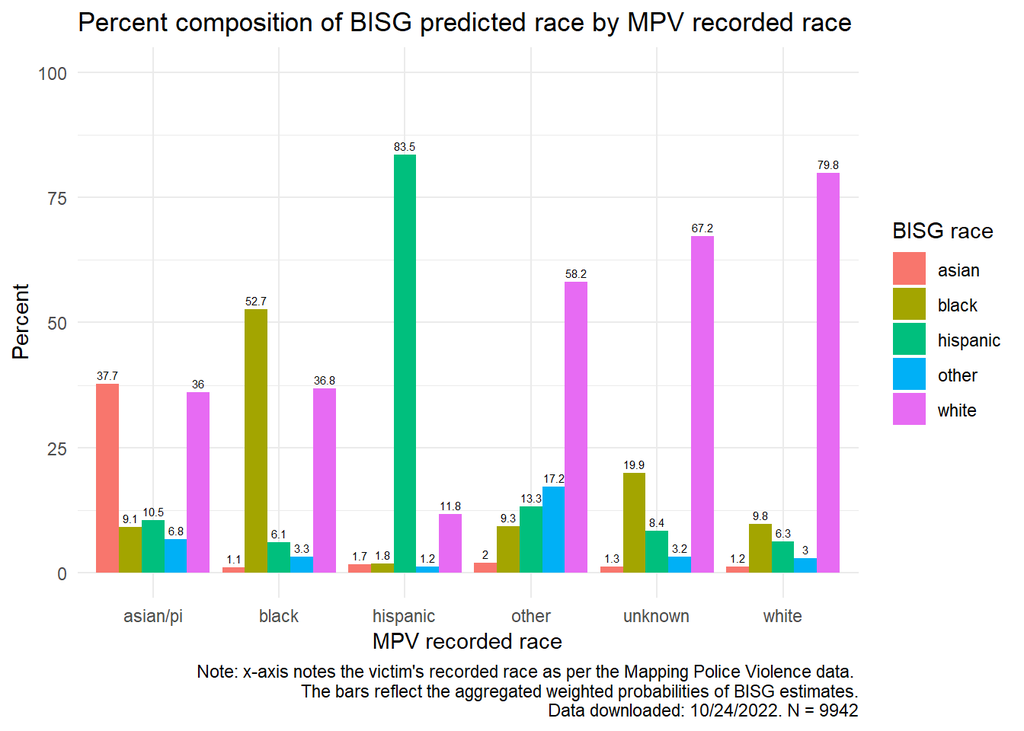

```r
police_df_slim_final$race_simp <- "white"
police_df_slim_final$race_simp[police_df_slim_final$Victim.s.race=="Black"] <- "black"
police_df_slim_final$race_simp[police_df_slim_final$Victim.s.race=="Asian"] <- "asian/pi"
police_df_slim_final$race_simp[police_df_slim_final$Victim.s.race=="Pacific Islander"] <- "asian/pi"
police_df_slim_final$race_simp[police_df_slim_final$Victim.s.race=="Hispanic"] <- "hispanic"
police_df_slim_final$race_simp[police_df_slim_final$Victim.s.race=="Native American"] <- "other"
police_df_slim_final$race_simp[police_df_slim_final$Victim.s.race=="Unknown race"] <- "unknown"

### collapse the data
police_df_slim_final_col <- police_df_slim_final %>%
  group_by(race_simp) %>%
  summarise(white=sum(pred_whi),black=sum(pred_bla), hispanic=sum(pred_his) ,asian=sum(pred_asi),
            other=sum(pred_oth))
### get total
total_num <- rowSums(police_df_slim_final_col[,2:6])
## get pcts
police_df_slim_final_col_pct <- (police_df_slim_final_col[,2:6]/total_num)*100

## bind prior df first col
police_df_slim_final_col_pct <- cbind(police_df_slim_final_col[,1],police_df_slim_final_col_pct)

### now make long
police_df_slim_final_col_pct_long <- police_df_slim_final_col_pct %>%
  pivot_longer(!race_simp, names_to="predicted_race", values_to = "percent" )
police_df_slim_final_col_pct_long$percent <- round(police_df_slim_final_col_pct_long$percent,1)

### now, let's look at diffs in overall counts

overall_race_diff <- ggplot(police_df_slim_final_col_pct_long, aes(fill=predicted_race, y=percent, x=race_simp, label=percent)) +
    geom_bar(position="dodge", stat="identity") + theme_minimal() +ylim(0,100) +
  labs(title="Percent composition of BISG predicted race by MPV recorded race",
       x="MPV recorded race",
       y="Percent",fill="BISG race",
       caption=paste0("Note: x-axis notes the victim's recorded race as per the Mapping Police Violence data.
       The bars reflect the aggregated weighted probabilities of BISG estimates.
       Data downloaded: 10/24/2022. N = ", sum(total_num) )) +
    geom_text(position = position_dodge(width = .9),    # move to center of bars
              vjust = -0.5,    # nudge above top of bar
              size = 2)


overall_race_diff
```

## Analyzing the precision rate

We ultimately care about the precision rating, or the true positive over the positives. We want to know the probability that one is of race i, given that the BISG predicted probability assigns them race i.[^3] We see in the results below, the results are fairly strong. The precision proceeds in the order of Hispanic, Black, White, Asian/PI, and Other.

The highest rating for Hispanics sees a precision rating of approximately 85 percent given the BISG assigned race, with most of the error arising from 8.9 percent of Hispanics assigned incorrectly as White.[^4] African-Americans in turn see 80.4 percent correct matching, with the error almost entirely arising with the 17.3 percent of the time when the race should be White. White victims in turn see approximately 75 percent correct identification, with most of the error arising in approximately 19 percent of the time when the victim should be coded as African American. Both Asian/Pacific Islanders and victims that fall into the “Other” category see a greater distribution of error. While nearly 69 percent of the time the BISG assigned category of Asian-Pacific Islander is correct, the assignment is in error 15.7 percent of the time for Whites, which is equivalent to the aggregated error for African Americans, Hispanics, and Other. The category of “Other” for police violence victims – which comprises mostly Native Americans – sees the greatest amount of noise, with only correct assignment 40.4 percent of the time. These results suggest special caution in missing the toll of police violence on Native Americans, and perhaps alternative BISG methodologies for these purposes.

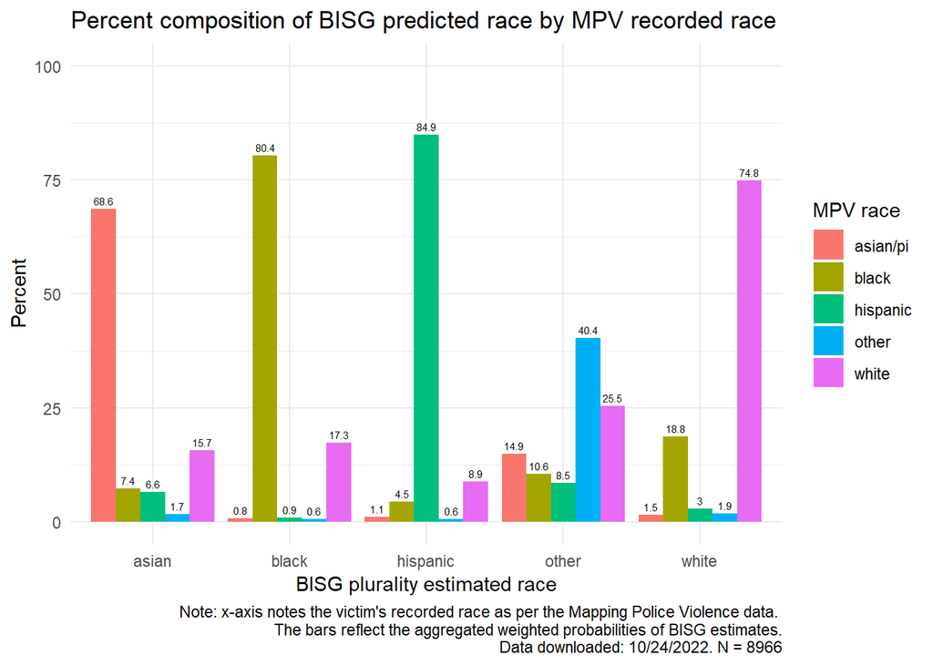

```r
### use the herfindahl fxn to get plural race
police_df_slim_final <- race_herfindahl_scores2(police_df_slim_final)

### now have the plural_race; match
police_df_slim_final <- subset(police_df_slim_final,race_simp != "unknown"  )


### collapse the data
police_df_slim_final_col <- police_df_slim_final %>%
  group_by(plural_race,race_simp) %>%
  tally()
### get total
total_num <- sum(police_df_slim_final_col$n)
## get pcts; mutate
police_df_slim_final_col <- police_df_slim_final_col %>%
  group_by(plural_race) %>%
  mutate(plural_sum=sum(n))
police_df_slim_final_col$pct <- round((police_df_slim_final_col$n/police_df_slim_final_col$plural_sum)*100,1)



### let's create a ggplot
overall_precision_plot <- ggplot(police_df_slim_final_col, aes(fill=race_simp, y=pct, x=plural_race, label = (pct))) +
    geom_bar(position="dodge", stat="identity") + theme_minimal() +ylim(0,100) +
  labs(title="Percent composition of BISG predicted race by MPV recorded race",
       x="BISG plurality estimated race",
       y="Percent",
       caption=paste0("Note: x-axis notes the victim's recorded race as per the Mapping Police Violence data.
       The bars reflect the aggregated weighted probabilities of BISG estimates.
       Data downloaded: 10/24/2022. N = ", sum(total_num) ), fill="MPV race" ) +
  geom_text(position = position_dodge(width = .9),    # move to center of bars
              vjust = -0.5,    # nudge above top of bar
              size = 2)
overall_precision_plot
```

## Breaking the results down by police withholding name

Looking at the data, we see that the imputations are mostly accurate, but not perfect. Notably, there is an underestimate for the number of African American victims. Therefore, one basic check is the level by which these results arose. Overall, we see that most of the times that names were withheld – at 179 cases – were when the race of the victim was also unknown. There is suggestive evidence that withholding the surname for victims of Hispanic descent does greatly reduce the accuracy of BISG. While few in number, the cases where the police withheld an African American victim’s name appears to exhibit greater accuracy. However, the data are too few.

```r
## collapse the data
police_df_slim_final_col <- police_df_slim_final %>%
  group_by(race_simp,name_withheld) %>%
  summarise(white=sum(pred_whi),black=sum(pred_bla), hispanic=sum(pred_his) ,asian=sum(pred_asi),
            other=sum(pred_oth))
### get total
total_num <- rowSums(police_df_slim_final_col[,3:7])
## get pcts
police_df_slim_final_col_pct <- round((police_df_slim_final_col[,3:7]/total_num)*100,2)

## bind prior df first col
police_df_slim_final_col_pct <- cbind(police_df_slim_final_col[,1:2],total_num, police_df_slim_final_col_pct)
colnames(police_df_slim_final_col_pct)[3] <- "total_num"

### change name withheld
police_df_slim_final_col_pct$name_withheld[police_df_slim_final_col_pct$name_withheld==0] <- "Provided"
police_df_slim_final_col_pct$name_withheld[police_df_slim_final_col_pct$name_withheld==1] <- "Withheld"

## present the table
knitr::kable(police_df_slim_final_col_pct, caption="Accuracy of BISG relative to MPV by whether name was
             withheld.")
```

Accuracy of BISG relative to MPV by whether name was withheld.

| race_simp | name_withheld | total_num | white | black | hispanic | asian | other |
| --- | --- | --- | --- | --- | --- | --- | --- |
| asian/pi | Provided | 201 | 36.03 | 9.03 | 10.30 | 37.81 | 6.83 |
| asian/pi | Withheld | 1 | 26.87 | 25.27 | 41.19 | 6.67 | 0.00 |
| black | Provided | 2486 | 36.85 | 52.66 | 6.07 | 1.12 | 3.30 |
| black | Withheld | 12 | 27.43 | 65.31 | 3.82 | 0.32 | 3.11 |
| hispanic | Provided | 1757 | 11.44 | 1.57 | 84.14 | 1.76 | 1.09 |
| hispanic | Withheld | 20 | 47.14 | 18.13 | 27.06 | 0.68 | 6.99 |
| other | Provided | 136 | 58.40 | 9.41 | 13.51 | 2.00 | 16.68 |
| other | Withheld | 3 | 49.32 | 6.43 | 2.43 | 3.05 | 38.76 |
| white | Provided | 4339 | 79.77 | 9.79 | 6.32 | 1.17 | 2.96 |
| white | Withheld | 11 | 72.72 | 21.67 | 2.29 | 0.47 | 2.85 |

## Anlyzing error via multi-level modeling

There is reason to believe that there are unobserved features that predict error. While we will keep analyses simple here for now, it might be the case that factors such as segregation lead to bias in results. Where segregation occurs, the aggregated levels of geography become less informative due to clustering, which can likewise lead to bias. Additionally, highly segregated areas might see the type of racial animus associated with police violence. Therefore, we explore the likelihood of error with a simple multilevel logistic regression. We will employ random intercepts by county. The outcome of interest is whether the plurality BISG estimated race matches the MPV recorded race. We will exclude the unknown race, since we cannot validate against these observations.

Of interest will be the segregation index, recorded via the Duncan-Duncan index. The measure incorporates spatial adjacency on what proportion of the county would need to move in order to make every Census Block Group a microcosm of the county. Scores near 0 equate to no segregation, and scores near 1 equate to complete segregation. I acquired these data from the county ACS data, which I created from my time at the MIT Elections Data and Science Lab in 2020.

Other variables of interest at the county level are the gini index, with scores near 0 reflecting complete equality and scores near 1 reflecting complete inequality. We likewise will incorporate metro type, defined by the National Center for Health Statistics’ 2013 urban-rural classification scheme of counties. These include: Large metro, medium metro, small metro, micropolitan, and non-core (rural) areas.

```r
## change the pred_ names in order to get the plural estimates easily
police_df_slim_final <- readRDS("data/police_df_slim_final_w_county_acs.rds")


### make the names match
police_df_slim_final$race_simp <- "white"
police_df_slim_final$race_simp[police_df_slim_final$Victim.s.race=="Black"] <- "black"
police_df_slim_final$race_simp[police_df_slim_final$Victim.s.race=="Asian"] <- "asian"
police_df_slim_final$race_simp[police_df_slim_final$Victim.s.race=="Pacific Islander"] <- "asian"
police_df_slim_final$race_simp[police_df_slim_final$Victim.s.race=="Hispanic"] <- "hispanic"
police_df_slim_final$race_simp[police_df_slim_final$Victim.s.race=="Native American"] <- "other"
police_df_slim_final$race_simp[police_df_slim_final$Victim.s.race=="Unknown race"] <- "unknown"

### now have the plural_race; match
police_df_slim_final <- subset(police_df_slim_final,race_simp != "unknown"  )

### create dummy var
police_df_slim_final$race_match <- 0
police_df_slim_final$race_match[police_df_slim_final$race_simp==police_df_slim_final$plural_race] <- 1

### get summary
summary(police_df_slim_final$race_match) # same 77% of time
```

[output not shown]

```r
quantile(police_df_slim_final$duncan_index, c(0.25,0.5,0.75), na.rm=T)
```

```
##       25%       50%       75%
## 0.2736453 0.3491494 0.4414297
```

```r
### create mlm model
conflicts_prefer(arm::logit)
```

```
## [conflicted] Will prefer arm::logit over any other package.
```

```r
# commented out model for time; uncomment out to read back in
#race_model <- glmer(race_match ~ duncan_index + gini_index +
#                      as.factor(metro_type) + (1|county_fips), data=police_df_slim_final,
#                      family=binomial(link=logit)  )
# saveRDS(race_model, "data/models/race_model_re.rda")
race_model <- readRDS("data/models/race_model_re.rda")
summary(race_model)
```

```
## Generalized linear mixed model fit by maximum likelihood (Laplace
##   Approximation) [glmerMod]
##  Family: binomial  ( logit )
## Formula: race_match ~ duncan_index + gini_index + as.factor(metro_type) +
##     (1 | county_fips)
##    Data: police_df_slim_final
##
##      AIC      BIC   logLik deviance df.resid
##   9391.6   9448.4  -4687.8   9375.6     8951
##
## Scaled residuals:
##     Min      1Q  Median      3Q     Max
## -2.5999  0.3986  0.4772  0.5421  0.8849
##
## Random effects:
##  Groups      Name        Variance Std.Dev.
##  county_fips (Intercept) 0.1897   0.4355
## Number of obs: 8959, groups:  county_fips, 1650
##
## Fixed effects:
##                                   Estimate Std. Error z value Pr(>|z|)
## (Intercept)                        1.87323    0.54313   3.449 0.000563 ***
## duncan_index                      -1.60099    0.29585  -5.412 6.25e-08 ***
## gini_index                        -0.17725    1.18629  -0.149 0.881226
## as.factor(metro_type)Medium Metro  0.08548    0.10630   0.804 0.421349
## as.factor(metro_type)Micro         0.33134    0.13624   2.432 0.015015 *
## as.factor(metro_type)Noncore       0.23180    0.15057   1.539 0.123685
## as.factor(metro_type)Small Metro   0.09841    0.11136   0.884 0.376827
## ---
## Signif. codes:  0 '***' 0.001 '**' 0.01 '*' 0.05 '.' 0.1 ' ' 1
##
## Correlation of Fixed Effects:
##             (Intr) dncn_n gn_ndx a.(_)MM as.(_)M a.(_)N
## duncan_indx  0.192
## gini_index  -0.966 -0.393
## as.fct(_)MM -0.312 -0.088  0.190
## as.fctr(_)M -0.272  0.060  0.149  0.563
## as.fctr(_)N -0.256  0.105  0.133  0.505   0.422
## as.fct(_)SM -0.415  0.013  0.272  0.703   0.572   0.520
```

```r
### now plot the results
set.seed(1337)
random_beta_draws <- mvrnorm(10000, mu=fixef(race_model), Sigma=vcov.merMod(race_model))

### now, proceed to create a df to predict upon
seg_seq <- seq(0,1,by=0.01) # create range for seg
df_apply <- data.frame(cbind(1,seg_seq, mean(police_df_slim_final$gini_index, na.rm=T),1,0,0,0))

### apply with matrix mult
pred_probs <- as.matrix(df_apply) %*% t(random_beta_draws)
## now, apply the results
pred_probs <- inv.logit(pred_probs)
pred_prob_df <-apply(pred_probs, 1,quantile, probs=c(0.025,.5,.975) )
dim(pred_prob_df)
```

```
## [1]   3 101
```

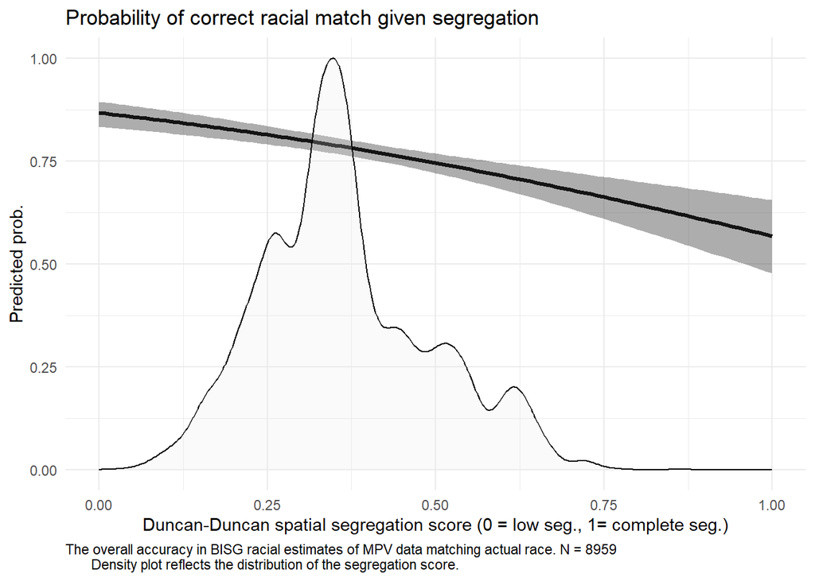

```r
## #now lets get into a nic df
pred_prob_df <- t(pred_prob_df)
pred_prob_df <- as.data.frame(pred_prob_df)
colnames(pred_prob_df) <- c("low_ci","median_est","upp_ci")
pred_prob_df <- cbind(pred_prob_df, seg_seq)
colnames(pred_prob_df)[4] <- "segregation"

### now, plot the results
segreg_ggplot_reg <- ggplot(pred_prob_df, aes(x=segregation, y=median_est)) +
  geom_line(lwd=1.2) +
  geom_ribbon(aes(ymin=low_ci,ymax=upp_ci), alpha=0.4) + #### very important command; makes the CIs
  theme_minimal() + ## cleans up the presentation of the plot
  ylim(0,1) + labs(title="Probability of correct racial match given segregation", x="Duncan-Duncan spatial segregation score (0 = low seg., 1= complete seg.)",
       y="Predicted prob.",
       caption="The overall accuracy in BISG racial estimates of MPV data matching actual race. N = 8959
       Density plot reflects the distribution of the segregation score."
       ) +
  geom_density(police_df_slim_final, mapping= aes(x=duncan_index,y=..scaled..), fill="gray90", alpha=0.2) +
  theme(plot.caption = element_text(hjust = 0))
segreg_ggplot_reg
```

## Identifying the locations of police violence

```r
### create var to sum
police_df_slim_final$dum = 1

num_agencies <- police_df_slim_final %>%
  group_by(Agency.responsible.for.death,state_po) %>%
  summarise(total_deaths = sum(dum), total_pop=median(total_pop,na.rm=T),
            duncan_index=median(duncan_index,na.rm=T))
### get deaths per million
num_agencies$deaths_per_mil <- (num_agencies$total_deaths/num_agencies$total_pop)*1000000


summary(num_agencies$total_deaths) ## ok, one is really bad
```

```
##    Min. 1st Qu.  Median    Mean 3rd Qu.    Max.
##   1.000   1.000   1.000   2.465   2.000 145.000
```

```r
quantile(num_agencies$total_deaths, seq(0,1,by=0.05)) # hige jump at 5 percent
```

```
##   0%   5%  10%  15%  20%  25%  30%  35%  40%  45%  50%  55%  60%  65%  70%  75%
##    1    1    1    1    1    1    1    1    1    1    1    1    1    1    2    2
##  80%  85%  90%  95% 100%
##    2    3    4    7  145
```

```r
quantile(num_agencies$total_deaths, seq(0.95,1,by=0.01)) # hige jump at 5 percent
```

```
##    95%    96%    97%    98%    99%   100%
##   7.00   9.00  12.00  15.28  25.64 145.00
```

```r
top1percent <- num_agencies %>%
  dplyr::filter(total_deaths >25)
sum(top1percent$total_deaths)/nrow(police_df_slim_final)
```

```
## [1] 0.20087
```

```r
### what about the county weighted per million numbers?
quantile(num_agencies$deaths_per_mil, seq(0,1,by=0.05)) # hige jump at 5 percent
```

```
##           0%           5%          10%          15%          20%          25%
##    0.0990290    0.5192472    0.9968348    1.3657247    1.8954475    2.6472605
##          30%          35%          40%          45%          50%          55%
##    3.5885253    4.7369519    6.0721321    7.6019035    9.7010147   11.9902649
##          60%          65%          70%          75%          80%          85%
##   14.8940935   18.2705132   21.9770560   25.7891479   31.9974773   41.2933064
##          90%          95%         100%
##   52.8772320   81.0706070 1282.5210700
```

```r
### 81 appears the 95th pctile
quantile(num_agencies$deaths_per_mil, seq(0.95,1,by=0.001))
```

```
##        95%      95.1%      95.2%      95.3%      95.4%      95.5%      95.6%
##   81.07061   82.34403   84.45435   86.31107   86.86747   87.36486   89.19117
##      95.7%      95.8%      95.9%        96%      96.1%      96.2%      96.3%
##   89.65569   90.92711   91.50889   92.63216   93.86802   95.73317   97.05608
##      96.4%      96.5%      96.6%      96.7%      96.8%      96.9%        97%
##   98.56101  101.68566  104.79332  106.46417  107.97419  110.88933  113.42597
##      97.1%      97.2%      97.3%      97.4%      97.5%      97.6%      97.7%
##  115.73970  116.88675  120.67525  124.13360  126.21482  127.73012  132.09041
##      97.8%      97.9%        98%      98.1%      98.2%      98.3%      98.4%
##  136.14338  139.11655  141.25453  145.41565  147.32966  148.96470  153.50865
##      98.5%      98.6%      98.7%      98.8%      98.9%        99%      99.1%
##  160.19142  165.15160  178.51808  187.05792  198.14774  209.58559  229.01719
##      99.2%      99.3%      99.4%      99.5%      99.6%      99.7%      99.8%
##  236.64064  242.05065  269.83015  298.84271  339.32426  472.50913  526.33412
##      99.9%       100%
##  603.58670 1282.52107
```

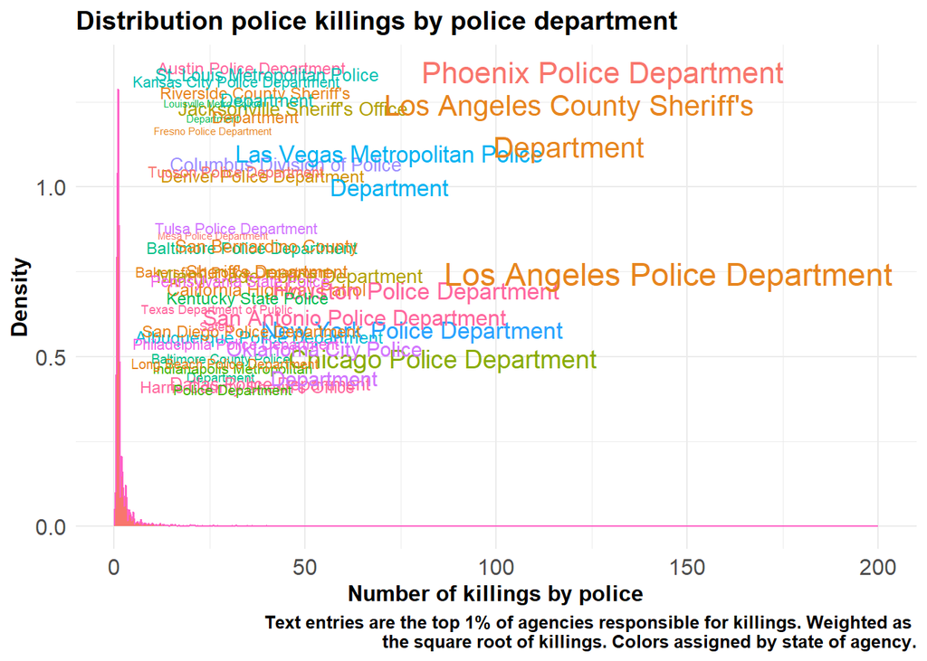

```r
### want to control for culture
num_agencies$y_pos = 0.3 + runif(nrow(num_agencies), min=0.1,max=1.1)
### create a plot for the num og agencies, distribution
num_agencies$n10 = num_agencies$total_deaths
update_geom_defaults("text", list(size = 24))
agency_kill_dist <- ggplot(data=num_agencies, aes(x=total_deaths, fill="Police killings",col="Police killings")) +
  geom_density() +  theme_minimal() + theme(legend.position="none") +
  geom_text(data=subset(num_agencies,total_deaths>25), aes(y=y_pos, x=total_deaths,
                                                label=stringr::str_wrap(Agency.responsible.for.death,30), size=n10,
                                                col=as.factor(state_po))) +
  xlim(0,200) + labs(title="Distribution police killings by police department",y="Density",
                     x="Number of killings by police",
                     caption="Text entries are the top 1% of agencies responsible for killings. Weighted as
                     the square root of killings. Colors assigned by state of agency.")+
  theme(axis.text=element_text(size=12),
        title=element_text(size=12,face="bold"),legend.text = element_text(size=10)) +
  scale_size(
    breaks = c(10, 50, 100, 150),
    range = c(2, 6)
  )
ggsave("plots/agency_shooting_dist.jpeg",
       plot=agency_kill_dist, scale=1,width=9,
       height=6,units = c("in"),dpi=600, bg="white")


agency_kill_dist
```

However, it is also the case that most of the above police departments serve major metropolitan areas. The greater number of people means a likely lower rate of those killed by police across the population. Therefore, it is also possible to divide the number of killings by the population served. We will use the county as a denominator, since we do not have the data right now to map out the entire jurisdiction. Running the results by killings per million reveals a different pattern. Now, a new set of agencies kill disproportionately more relative to the people they serve. The top 1 percent kill approximately 200 per million. The top 5 agencies within the data are the Kentucky State Police, Nye County Sheriff’s Office and Esmeralda County Sheriff’s Office in Nevada, Foard County Sheriff’s Office of Texas, Kiowa County Sheriff’s Office of Colorado, and finally the New Mexico State Police. It should be noted that all but the Kentucky and New Mexico police above killed one person, though these happen to be sparsely populated counties.

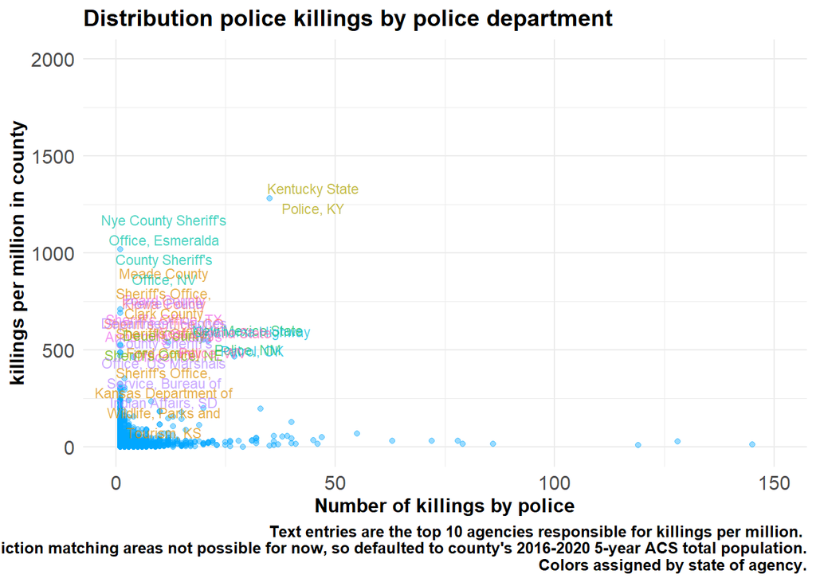

```r
#### now, let's get the results by the per million; scatter plot
agency_kill_dist_per_million <- ggplot(data=num_agencies, aes(x=total_deaths,y=deaths_per_mil, fill="Police killings",col="Police killings")) +
  geom_point(alpha=0.4) +
  theme_minimal() + theme(legend.position="none") +
  geom_text(data=subset(num_agencies, deaths_per_mil > 487) ,aes(label=stringr::str_wrap(paste0(Agency.responsible.for.death, sep=", ", state_po),20), x=total_deaths + 10,
                                                col=as.factor(state_po)),alpha=0.7,size=3) +
  xlim(0,150) + labs(title="Distribution police killings by police department",y="killings per million in county",
                     x="Number of killings by police",
                     caption="Text entries are the top 10 agencies responsible for killings per million. \n Jurisdiction matching areas not possible for now, so defaulted to county's 2016-2020 5-year ACS total population.\n Colors assigned by state of agency.")+
  theme(axis.text=element_text(size=12),
        title=element_text(size=12,face="bold"),legend.text = element_text(size=10)) +
  scale_size(
    breaks = c(10, 50, 100, 150),
    range = c(2, 6)
  ) + ylim(0,2000)
ggsave("plots/agency_shooting_dist_per_million.jpeg",
       plot=agency_kill_dist_per_million, scale=1,width=9,
       height=6,units = c("in"),dpi=600, bg="white")

agency_kill_dist_per_million
```

## Characteristics by segregation and demographics

We finally take a look at the county characteristics where police killed the victims. Of special interest are how segregated and White a county is. A common reason given for pulling individuals over is that they seem to be “out of place,” i.e., the race of the victim does not match that of the area. When plotting the results, we see that police killed their victims in a county with a median White percent of approximately 57 percent. Additionally, the median segregation score is approximately 0.35, suggesting that 35 percent of the population would need to move in order to make each block group a microcosm of the county’s racial demographics.

When plotting the results by race of victim, we see no strong relationship. When plotting the loess curve, there is suggestive evidence that police tend to kill victims in more white and less segregated counties. However, the results are fairly weak.

```r
police_df_slim_final <- readRDS("data/police_df_slim_final_w_county_acs.rds")

### use the herfindahl fxn to get plural race
police_df_slim_final <- race_herfindahl_scores2(police_df_slim_final)

### make the names match
police_df_slim_final$race_simp <- "white"
police_df_slim_final$race_simp[police_df_slim_final$Victim.s.race=="Black"] <- "black"
police_df_slim_final$race_simp[police_df_slim_final$Victim.s.race=="Asian"] <- "asian"
police_df_slim_final$race_simp[police_df_slim_final$Victim.s.race=="Pacific Islander"] <- "asian"
police_df_slim_final$race_simp[police_df_slim_final$Victim.s.race=="Hispanic"] <- "hispanic"
police_df_slim_final$race_simp[police_df_slim_final$Victim.s.race=="Native American"] <- "other"
police_df_slim_final$race_simp[police_df_slim_final$Victim.s.race=="Unknown race"] <- "unknown"

### create final category, this time with imputed race
police_df_slim_final$final_race <- police_df_slim_final$race_simp
police_df_slim_final$final_race[police_df_slim_final$race_simp=="unknown"] <-
  police_df_slim_final$plural_race[police_df_slim_final$race_simp=="unknown"]

### check out dist of white pct
quantile(police_df_slim_final$white_pct, seq(0,1,by=0.05))
```

```
##         0%         5%        10%        15%        20%        25%        30%
##  0.7277679 26.3323263 29.0937543 30.6232805 35.9364340 40.8228466 43.4918896
##        35%        40%        45%        50%        55%        60%        65%
## 47.4412332 52.2567326 55.6869875 57.9791290 62.3426488 65.5601565 69.1630284
##        70%        75%        80%        85%        90%        95%       100%
## 72.2637283 76.3733973 80.1714270 83.9485921 87.7297980 92.3544988 99.5657666
```

```r
quantile(police_df_slim_final$duncan_index, seq(0,1,by=0.05),na.rm=T)
```

```
##        0%        5%       10%       15%       20%       25%       30%       35%
## 0.0000000 0.1757119 0.2126219 0.2402003 0.2569155 0.2718593 0.2985626 0.3188870
##       40%       45%       50%       55%       60%       65%       70%       75%
## 0.3233414 0.3379037 0.3466902 0.3605203 0.3653384 0.3815521 0.4053109 0.4395998
##       80%       85%       90%       95%      100%
## 0.4707272 0.5106546 0.5499595 0.6117481 0.8619311
```

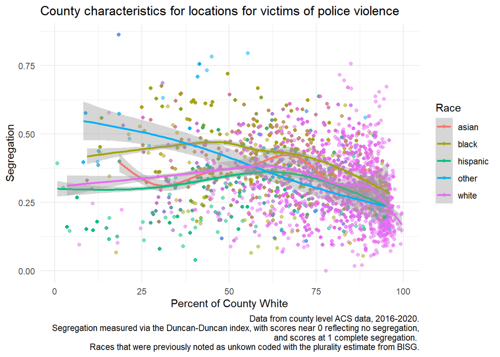

```r
#### now, plot the results
scatter_plot_demos <- ggplot(data=police_df_slim_final, aes(x=white_pct, y=duncan_index, color=final_race)) +
  geom_point(alpha=0.5) + theme_minimal() + geom_smooth() +
  labs(title="County characteristics for locations for victims of police violence",y="Segregation",
                     x="Percent of County White", color="Race",
                     caption="Data from county level ACS data, 2016-2020.\n Segregation measured via the Duncan-Duncan index, with scores near 0 reflecting no segregation,\n and scores at 1 complete segregation. \n Races that were previously noted as unkown coded with the plurality estimate from BISG.")
ggsave("plots/white_pct_seg_plot.jpeg",
       plot=scatter_plot_demos, scale=1,width=9,
       height=6,units = c("in"),dpi=600, bg="white")
scatter_plot_demos
```

```r
### check out dist of white pct
quantile(police_df_slim_final$gini_index, seq(0,1,by=0.05),na.rm=T)
```

```
##       0%       5%      10%      15%      20%      25%      30%      35%
## 0.351300 0.407600 0.423100 0.430585 0.437800 0.443200 0.448400 0.454600
##      40%      45%      50%      55%      60%      65%      70%      75%
## 0.458300 0.461700 0.465200 0.466600 0.469400 0.473800 0.479800 0.485700
##      80%      85%      90%      95%     100%
## 0.491600 0.499700 0.502200 0.514615 0.597100
```

```r
quantile(county_acs_slim$gini_index, seq(0,1,by=0.05),na.rm=T)
```

```
##      0%      5%     10%     15%     20%     25%     30%     35%     40%     45%
## 0.25670 0.39190 0.40238 0.41030 0.41570 0.42160 0.42680 0.43120 0.43520 0.43961
##     50%     55%     60%     65%     70%     75%     80%     85%     90%     95%
## 0.44430 0.44860 0.45388 0.45860 0.46340 0.46930 0.47610 0.48350 0.49522 0.51262
##    100%
## 0.66470
```

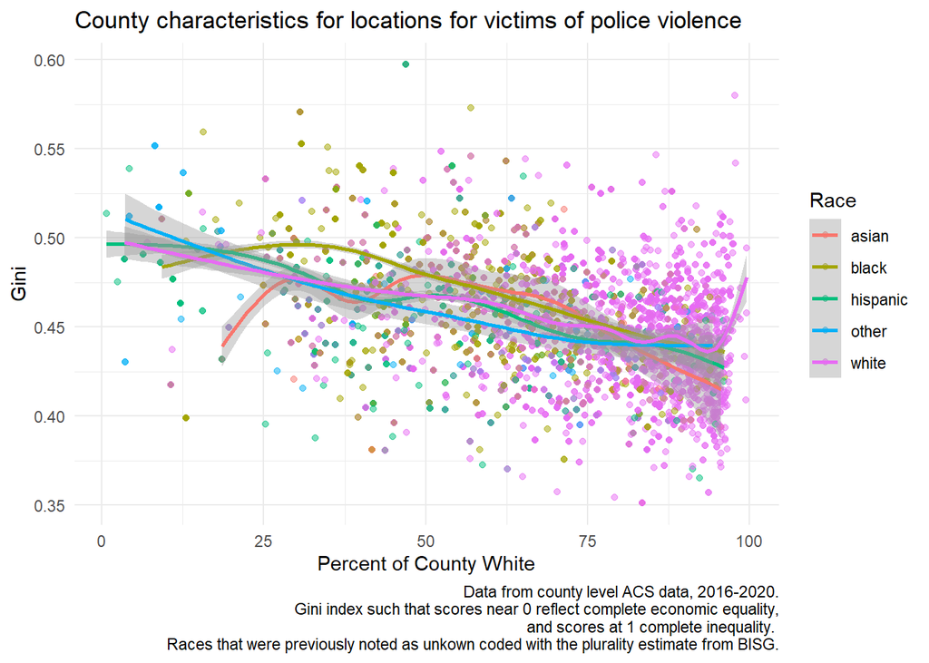

```r
#### now, plot the results
scatter_plot_gini <- ggplot(data=police_df_slim_final, aes(x=white_pct, y=gini_index, color=final_race)) +
  geom_point(alpha=0.5) + theme_minimal() + geom_smooth() +
  labs(title="County characteristics for locations for victims of police violence",y="Gini",
                     x="Percent of County White", color="Race",
                     caption="Data from county level ACS data, 2016-2020.\n Gini index such that scores near 0 reflect complete economic equality,\n and scores at 1 complete inequality. \n Races that were previously noted as unkown coded with the plurality estimate from BISG.")
ggsave("plots/white_pct_gini_plot.jpeg",
       plot=scatter_plot_gini, scale=1,width=9,
       height=6,units = c("in"),dpi=600, bg="white")
scatter_plot_gini
```

# Appendix

[^1]: https://mappingpoliceviolence.org/
[^2]: County data could be used, though for the purpose of this exercise, we see enough of a reduction in missing data that it is inefficient for the purposes of this tutorial, especially since the command is the same as it is for the ZIP code imputation.
[^3]: As I discuss elswhere (Clark, Curiel, Steelman, 2021; DeLuca and Curiel 2022; Curiel and DeLuca 2024) it is important to be cautious in applying the maximum posterior, i.e. plurality estimate of BISG. We lose information by not weighting the data by the confidence of the estimate. However, the dichotomous nature of categorization to a given category and prevalence of the precision statistic makes such analyses as will follow a measure of utility in ascertaining the validity of BISG to Mapping Police Violence.
[^4]: Note, it is common for Hispanics to identify as White, and one critique of the wru set up is that Hispanic is treated as zero-sum relative to the other racial categories. Such assignment is largely an artifact of the British conception of race.